# Winner selection

Zijun Gao

2024-10-20

## Warm-up: multivariate normal

Consider $X \in \mathbb{R}^d$, $X \sim \mathcal{N}(\mu, \Sigma)$. Here $\Sigma$ is typically not diagonal. Let $w^*$ denote the true winner, i.e., $w^* = \arg\min_i \mu_i$. We observe $n$ i.i.d. realizations of the multivariate normal. We select the coordinate with the minimal empirical mean as the winner, denoted by $\hat{w}$.

Define the null
$$\begin{align*}
H_{i <, 0}: \mu_i \ge \mu_j, \quad \text{for some}~j \neq i.
\end{align*}$$
We are interested in testing the null $H_{\hat{w} <,0}$, which depends on the selection $\hat{w}$. Provided with $\hat{w}$, we compute the individual one-sided p-value as $P_i := \Phi(X_{\hat{w}} - X_i; -\inf, 0)$, $i \neq \hat{w}$, where $\Phi(\cdot; a, b)$ denotes the CDF of the truncated normal supported on $(a, b)$. We further take the maximal value of all individual p-values $P := \max_{i \neq \hat{w}} P_i$.

If the selection is incorrect, i.e., $\hat{w} \neq w^*$, then $\mathbb{P}(H_{w^*<,0} ~\text{rejected} \mid \hat{w} = w^*)$ denotes the conditional type I error. If the selection is correct, i.e., $\hat{w} = w^*$, then $\mathbb{P}(H_{w^*<,0} ~\text{rejected} \mid \hat{w} = w^*)$ denotes the conditional power. The primary goal is to produce a test with reasonable conditional power while controlling the conditional type I error.

Discussion:

- Taking the maximum of individual p-values could be conservative, but seems unavoidable. In fact, consider the null $\mu_1 \approx \mu_2 \ll \mu_3, \ldots, \mu_d$, $w^* = 1$. Conditional on the event $\hat{w} = 2$, the maximal p-value approximately follows $U(0,1)$.
- Data carving might be useful: use part of the randomness for selection and reserve part of the randomness for inference.
- Can the method in Lee et.al. be more powerful?
- What if we aim to control the marginal type I error and improve the marginal power (marginalized over the selected winner $\hat{w}$)? Note that if we could select the right winner with probability at least $1 - \alpha$, then the marginal type I error is automatically protected.
- Future direction: instead of choosing only one winner, choose a set of candidate winners containing the winner. Here the null is: the selected set does not contain the winner.

```r
# Load necessary library
library(MASS)
```

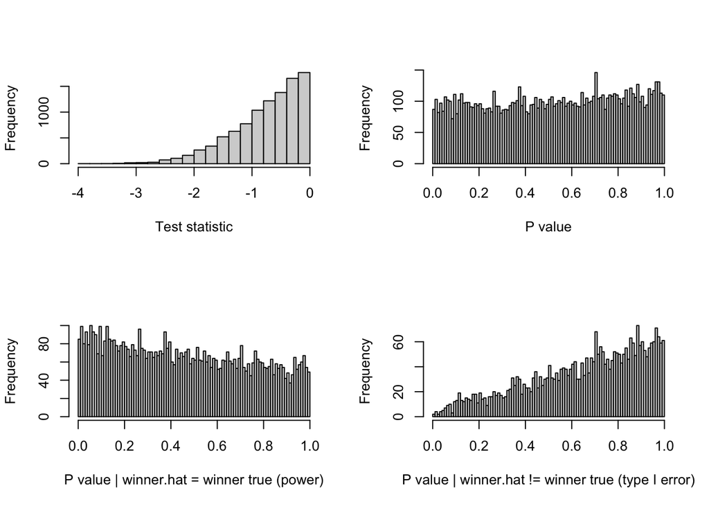

```r
set.seed(318)

# Set parameters
d = 3 # Dimension
p.value = rep(0, d)
mu = rep(0, d); mu[1] = -0.05 # Mean vector with the first element to be the winner, i.e., the coordinate with the smallest mu is the true winner
Sigma = matrix(0.8, nrow = d, ncol = d)  # Covariance matrix
diag(Sigma) = 1

n = 100  # Number of observations
m = 10000  # Number of simulation trials
record = list()
record$p.value = record$test.stats = record$correct.selection = rep(0, m)

# Simulation process
for (i in 1:m) {
  # Generate data
  X = mvrnorm(n = n, mu = mu, Sigma = Sigma)

  # Test statistics
  test.stats = apply(X, 2, mean)
  winner.hat = which.min(test.stats)  # Identify the minimum (the smaller, the better)

  # p-values
  sd.hat = apply(X - X[, rep(winner.hat, d)], 2, sd) / sqrt(n)
  p.value = pnorm((test.stats[winner.hat] - test.stats[-winner.hat]) / sd.hat[-winner.hat], 0, 1) / pnorm(0, 0, 1) # truncated normal on (-\inf, 0]

  # Record the max p-value and the corresponding test statistic
  record$p.value[i] = max(p.value)
  record$test.stats[i] = max((test.stats[winner.hat] - test.stats[-winner.hat]) / sd.hat[-winner.hat])
  winner.true = which.min(mu) # Suppose the true winner is unique
  record$correct.selection[i] = (winner.true == winner.hat)
}

# Plot histograms
par(mfrow = c(2, 2))
hist(record$test.stats, main = "", xlab = "Test statistic")
hist(record$p.value, xlim = c(0, 1), main = "", xlab = "P value", breaks = 100)
hist(record$p.value[record$correct.selection == 1], xlim = c(0, 1), main = "", xlab = "P value | winner.hat = winner true (power)", breaks = 100)
hist(record$p.value[record$correct.selection == 0], xlim = c(0, 1), main = "", xlab = "P value | winner.hat != winner true (type I error)", breaks = 100)
```

```r
alpha = 0.05
print("Type I error"); mean(record$p.value[record$correct.selection == 0] < alpha)
```

```
## [1] "Type I error"
```

```
## [1] 0.005217925
```

```r
print("Power"); mean(record$p.value[record$correct.selection == 1] < alpha)
```

```
## [1] "Power"
```

```
## [1] 0.06466924
```